# Donor Profile: Austria (Government of)

## Focus Portfolio

Austria’s 2025 funding portfolio demonstrates a concentrated impact opportunity with total donor contributions averaging $1.95 million, peaking at $6.6 million in key projects. This concentration signals high-leverage investment targets where additional resources can scale operations effectively. Despite overall solid funding, variability from $464,000 to $6.6 million across 14 initiatives highlights potential gaps that strategic donors can address to optimize UNHCR’s operational reach. Prioritizing partnerships with Austrian agencies focusing on high-funding regions can act as an impact multiplier, enhancing emergency response and resilience programming. Leveraging these investments as strategic priorities enables funders to fill critical financing gaps, reduce operational risk, and maximize accountability. Immediate action involves deepening donor engagement to channel funds into under-resourced projects within Austria’s portfolio, unlocking measurable results and innovation leadership in humanitarian response.

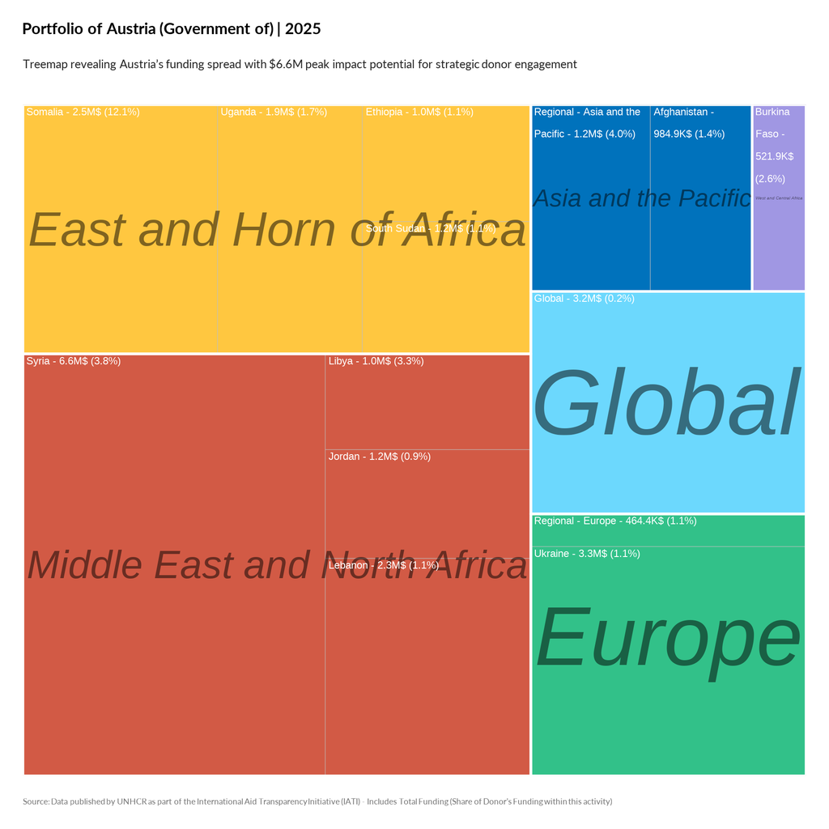

TRUE

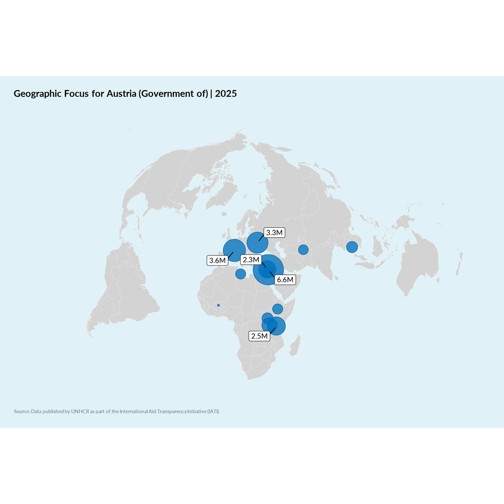

TRUE